# arch_backup_service

## **Arch Linux: Services and Timers**

#### *Creating a functioning backup.service and backup.timer pair*

**Context**  
Arch Linux is an incredibly powerful operating system, but documentation (including answers on StackOverflow) and [Red Hat](https://access.redhat.com/documentation/en-us/red_hat_enterprise_linux/7/html/system_administrators_guide/sect-Managing_Services_with_systemd-Unit_Files) on how to accomplish specific tasks are often a bit convoluted and not beginner-friendly.Case in point, I have been trying to create a timer-based backup service for my arch linux server, which I use to create a coding environment I can access on my Chromebook (thank you to the [code-server project](https://github.com/cdr/code-server)). Yes, I could just install the crontab package from the Arch AUR repository, but in the spririt of learning and of keeping my server operating system as minimal and lightweight as possible, I will use the built-in service-timer pair functionality in systemctl.  
The ArchWiki pages provide great detail on what systemctl [services](https://wiki.archlinux.org/index.php/Systemd/Timers#As_a_cron_replacement) and [timers](https://wiki.archlinux.org/index.php/Daemons) do, but not a lot of information on how to set them up.  
So, I am just going to dive in and see if I can create one without breaking my server and document my progress along the way.

**Project Goals**  
Create weekly and nightly backup timers using the Arch Linux .service-.timer pairs  
*WEEKLY BACKUP:* create a zipped, tarball backup of my entire drive. If my server crashes and I need to re-install Arch, I want to be able to restore all my custom bash files from before.  
*NIGHTLY BACKUP:*: git (or [git-annex](https://git-annex.branchable.com/)) commit incremental backup of my projects nightly so I have a nightly version-controlled backup of my important projects.

**Current project state**  
Currently I have my function saved as backup.sh in `/root`. To execute the backup, I have to run `./backup.sh` in bash  
*NOTE: To avoid errors in the jupyter notebook container, I have changed the folder names to reflect sample folders created in the container*

```bash
#
# backup.sh
# tar backup script to be run weekly
# backup all system files to /mnt/backup/Linux Backups/Arch-server

# mount External HD
sudo mount /dev/sdXYZ /mnt/path_to_HD

# set timestamp
TIMESTAMP=$(date +%m.%d.%Y);

#set destination filename
FILENAME="code-server-$TIMESTAMP.tar";

#set destination path
DESTINATION="backup_folder_ex"   # replace with "mnt/path_to_HD/backup_folder"


# set source folder
SOURCEFOLDER="source_folder"   # replace with "root"

echo "Backing up $SOURCEFOLDER to $DESTINATION/$FILENAME"
date
echo

#create backup
tar -cpzf $DESTINATION/$FILENAME $SOURCEFOLDER

#print confirmation
echo
echo "Backup Finished"
echo "Source folder: $SOURCEFOLDER"
echo "Saved as: $DESTINATION/$FILENAME"


# unmount External HD for security
sudo umount /mnt/path_to_HD
echo "External HD disconnected"
```

[output not shown]

### **Weekly Automation**

I have decided to use the Realtime timer (description from ArchWiki below) so that I can set it to run sometime when I most likely won't be awake and using the server coding environment. If for some reason I leave the server off for over a week or on the day it is supposed to run, I definitely want to employ the option `Persistent=True`

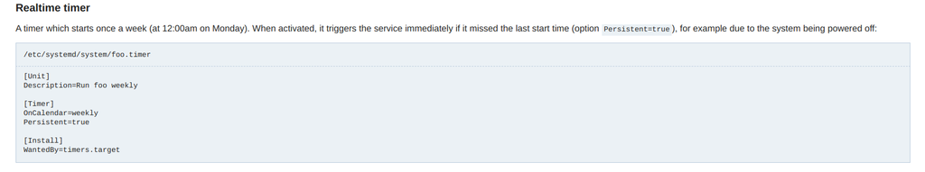

From the ArchWiki [systemd](https://wiki.archlinux.org/index.php/Systemd#Writing_custom_.service_files), [systemd/Timers](https://wiki.archlinux.org/index.php/Systemd/Timers#As_a_cron_replacement), and the [systemd.service man-page](https://jlk.fjfi.cvut.cz/arch/manpages/man/systemd.service.5), it looks like I need to create a backup.timer file and a backup.service file and put them in the `/etc/systemd/system` folder. The backup.service file will also have to call the backup.sh script. In the `/etc/systemd/system/mutli-user.targer.wants` folder, I also found the `docker.service` and `ssh.service` files, which will serve as a template:

```bash
# docker.service

[Unit]
Description=Docker Application Container Engine
Documentation=https://docs.docker.com
After=network-online.target docker.socket firewalld.service
Wants=network-online.target
Requires=docker.socket

[Service]
Type=notify
# the default is not to use systemd for cgroups because the delegate issues still
# exists and systemd currently does not support the cgroup feature set required
# for containers run by docker
ExecStart=/usr/bin/dockerd -H fd://
ExecReload=/bin/kill -s HUP $MAINPID
LimitNOFILE=1048576
# Having non-zero Limit*s causes performance problems due to accounting overhead
# in the kernel. We recommend using cgroups to do container-local accounting.
LimitNPROC=infinity
LimitCORE=infinity
# Uncomment TasksMax if your systemd version supports it.
# Only systemd 226 and above support this version.
#TasksMax=infinity
TimeoutStartSec=0
# set delegate yes so that systemd does not reset the cgroups of docker containers
Delegate=yes
# kill only the docker process, not all processes in the cgroup
KillMode=process
# restart the docker process if it exits prematurely
Restart=on-failure
StartLimitBurst=3
StartLimitInterval=60s

[Install]
WantedBy=multi-user.target

####################################################################################
# ssh.service


[Unit]
Description=OpenSSH Daemon
Wants=sshdgenkeys.service
After=sshdgenkeys.service
After=network.target

[Service]
ExecStart=/usr/bin/sshd -D
ExecReload=/bin/kill -HUP $MAINPID
KillMode=process
Restart=always

[Install]
WantedBy=multi-user.target
```

**backup.service**

```bash
# /etc/systemd/system/multi-user.target.wants/backup.service

[Unit]
Description=tar backup of all system files to be run weekly

[Service]
# will move backup.sh to /usr/bin
ExecStart=/usr/bin/backup.sh
# set type to 'oneshot: this is useful for scripts that do a single job and then exit.
# You may want to set RemainAfterExit=yes as well so that systemd still considers the
# service as active after the process has exited.'
Type=oneshot
RemainAfterExit=yes
KillMode=process
Restart=always

[Install]
WantedBy=multi-user.target
```

**backup.timer**

```bash
# /etc/systemd/system/backup.timer

[Unit]
Description=Run backup.sh weekly

[Timer]
# OnCalendar=weekly ... based on ArchWiki page, it looks like default 'weekly' is Mon at 12am
# but just to be sure it performs the backup while I'm offline, I am going to change it a bit
OnCalendar=Mon 02:00:00
Persistent=true

[Install]
WantedBy=timers.target
```

**Testing**  
Time to put the files in place and try activating the service by using `systemctl enable backup.service`  
Output of `systemctl enable backup.service`:  
`Failed to enable unit: Unit file backup.service does not exist.`  
Didn't work. Let's try putting both files one folder up just in the `etc/systemd/system`  
Output of `systemctl enable backup.service` now:  
`Created symlink /etc/systemd/system/multi-user.target.wants/backup.service → /etc/systemd/system/backup.service.`  
Looks like it worked! Out of curiosity, let's see if the symlink put anything new in the `multi-user.target.wants` folder...yep, looks like the symlink created a copy of `backup.service` in the `multi-user.target.wants` folder. Now let's start it and figure out how to make sure it is running.

**Start backup.service**

```bash
systemctl start backup.service
```

```
Failed to start backup.service: Unit backup.service has a bad unit file setting.
See system logs and 'systemctl status backup.service' for details.
```

```bash
systemctl status backup.service
```

```
● backup.service - tar backup of all system files to be run weekly
     Loaded: bad-setting (Reason: Unit backup.service has a bad unit file setting.)
     Active: inactive (dead)
Dec 17 18:20:07 code-server systemd[1]: backup.service: Service has Restart= set to either always or on-success, which isn't allowed for Type=oneshot services. Refusing.
```

Oops, looks like I can't use the `restart=always` option. Below is the updated `backup.service` file:

```bash
# /etc/systemd/system/multi-user.target.wants/backup.service

[Unit]
Description=tar backup of all system files to be run weekly

[Service]
# will move backup.sh to /usr/bin
ExecStart=/usr/bin/backup.sh
# set type to 'oneshot: this is useful for scripts that do a single job and then exit.
# You may want to set RemainAfterExit=yes as well so that systemd still considers the
# service as active after the process has exited.'
Type=oneshot
RemainAfterExit=yes
KillMode=process

[Install]
WantedBy=multi-user.target
```

Let's try again and see if it works now:  
`systemctl status backup.service`

[output not shown]

**Check Status**  
Alright, now that we've got `backup.service` started, let's see where we're at in terms of it running  
*Enabled services:*  
`systemctl list-unit-files | grep backup`

```
    backup.service                                                   enabled
    backup.timer                                                     disabled
```

Looks like we still need to enable `backup.timer`, so let's go ahead and do that...looks like that worked!  
Looks like everything is working, and a run of `systemctl restart backup.service` has created my first systemd-triggered archive file, and from here on out it should be triggered by `backup.timer`